# Section 2 - Perceptron vs Neural Networks

**Student Name: Xinyu Zhang**

**Student ID: 35486244**

## Q2 Neural Network’s Decision Boundary

### Q2-I

### Load Task2B train.csv and Task2B test.csv datasets, plot the training and testing data separately in two plots. Mark the data with different labels in different colors.

```python
# Importing required libraries
import matplotlib.pyplot as plt
import numpy as np
import sklearn
import sklearn.datasets
import sklearn.linear_model
import matplotlib
import pandas as pd
from sklearn.feature_extraction.text import CountVectorizer, TfidfVectorizer
from sklearn.cluster import KMeans
from sklearn.decomposition import PCA
from sklearn.feature_extraction.text import TfidfTransformer

import random
import os
from sklearn.metrics import zero_one_loss
from sklearn.linear_model import Perceptron
```

```python
# Display plots inline and change default figure size
%matplotlib inline
matplotlib.rcParams['figure.figsize'] = (10.0, 8.0)
```

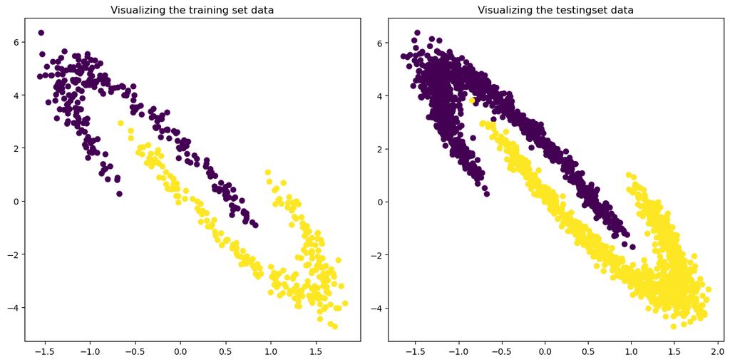

```python
# Load Task2B_train.csv and Task2B_test.csv datasets, plot the training and testing data separately in two plots.
# Mark the data with different labels in different colors.
Task2B_train_df = pd.read_csv("./Dataset_S2_2025/Task2B_train.csv")
Task2B_test_df = pd.read_csv("./Dataset_S2_2025/Task2B_test.csv")

# get the training data
features_train = np.array(Task2B_train_df[["feature1","feature2"]])
label_train = Task2B_train_df.label.values

# get the testign data
features_test = np.array(Task2B_test_df[["feature1", "feature2"]])
label_test = Task2B_test_df.label.values

# plot the testing data
_, axs = plt.subplots(1, 2, figsize=(12, 6), tight_layout=True)
axs[0].scatter(x=features_train[:,0],y=features_train[:,1], c=label_train)
axs[0].set_title('Visualizing the training set data')

# plot the training data
axs[1].scatter(x=features_test[:,0],y=features_test[:,1], c=label_test)
axs[1].set_title('Visualizing the testingset data')
plt.show()
```

### Q2-II

### Train two Perceptron models on the provided training data: one with early stopping and one without. For the model with early stopping, use a validation set comprising 20% of the training samples and you can set the threshold to 0.001. For both models, evaluate combinations of learning rates η ∈{0.001, 0.01, 0.1} and L2 regularisation strengths λ ∈ {0.0001, 0.001, 0.01, 0.1, 1.0}. Calculate the test errors for both models across all configurations, and identify the best-performing combination of η and λ for each model. Finally, plot the decision boundaries of both models with best η and λ along with the test data in a single figure.

```python
# Importing required libraries
from sklearn.model_selection import train_test_split
from sklearn.preprocessing import StandardScaler
from sklearn.metrics import zero_one_loss

# Data Preprocessing: Data Normalization
scaler = StandardScaler()
X_train_scaled = scaler.fit_transform(features_train)
X_test_scaled = scaler.transform(features_test)

# Define the hyperparameter combinations to be evaluated
learning_rates = [0.001, 0.01, 0.1]
lambda_strengths = [0.0001, 0.001, 0.01, 0.1, 1.0]

# Dictionary for storing information about the optimal model with and without early stopping
best_model_no_stopping = {'params': None, 'error': 1.0, 'model': None}
best_model_early_stopping = {'params': None, 'error': 1.0, 'model': None}
```

```python
# running the perceptron model without early stopping
print("Start training the perceptron model without early stopping")

for eta in learning_rates:
    for lam in lambda_strengths:
        # Create a perceptron model with L2 regularization
        perceptron = Perceptron(eta0=eta, penalty='l2', alpha=lam, max_iter=1000, tol=1e-3, random_state=42)

        # Train on the complete training data
        perceptron.fit(X_train_scaled, label_train)

        # Calculate the test error rate
        test_error = zero_one_loss(label_test, perceptron.predict(X_test_scaled))

        print(f"  η={eta}, λ={lam}, Test Error={test_error:.4f}")

        # record the parameters of the best model without early stopping
        if test_error < best_model_no_stopping['error']:
            best_model_no_stopping['error'] = test_error
            best_model_no_stopping['params'] = {'eta': eta, 'lambda': lam}
            best_model_no_stopping['model'] = perceptron
```

```
Start training the perceptron model without early stopping
  η=0.001, λ=0.0001, Test Error=0.1205
  η=0.001, λ=0.001, Test Error=0.1410
  η=0.001, λ=0.01, Test Error=0.1195
  η=0.001, λ=0.1, Test Error=0.1755
  η=0.001, λ=1.0, Test Error=0.1865
  η=0.01, λ=0.0001, Test Error=0.1410
  η=0.01, λ=0.001, Test Error=0.1195
  η=0.01, λ=0.01, Test Error=0.1755
  η=0.01, λ=0.1, Test Error=0.1865
  η=0.01, λ=1.0, Test Error=0.1245
  η=0.1, λ=0.0001, Test Error=0.1195
  η=0.1, λ=0.001, Test Error=0.1755
  η=0.1, λ=0.01, Test Error=0.1410
  η=0.1, λ=0.1, Test Error=0.1265
  η=0.1, λ=1.0, Test Error=0.1345
```

```python
best_model_no_stopping
```

```
{'params': {'eta': 0.001, 'lambda': 0.01},
 'error': 0.11950000000000005,
 'model': Perceptron(alpha=0.01, eta0=0.001, penalty='l2', random_state=42)}
```

```python
# running the perceptron model with early stopping
print("Start training the perceptron model with early stopping")
# Splitting the training and validation sets
X_train_part, X_val, y_train_part, y_val = train_test_split(
    X_train_scaled, label_train, test_size=0.2, random_state=42
)

for eta in learning_rates:
    for lam in lambda_strengths:
        # Create a perceptron model with L2 regularization
        # Stop training if the validation score does not improve for five consecutive epochs
        perceptron_es = Perceptron(eta0=eta, penalty='l2', alpha=lam, max_iter=1000, tol=1e-3,
                                   early_stopping=True, validation_fraction=0.2, n_iter_no_change=5, random_state=42)

        # Train on the complete training data
        perceptron_es.fit(X_train_scaled, label_train)

        # Calculate the validation error rate
        val_error = zero_one_loss(y_val, perceptron_es.predict(X_val))

        print(f"  η={eta}, λ={lam}, Validation Error={val_error:.4f}")

        # record the parameters of the best model with early stopping
        if val_error < best_model_early_stopping['error']:
            best_model_early_stopping['error'] = val_error
            best_model_early_stopping['params'] = {'eta': eta, 'lambda': lam}

            # record the final perceptron model
            final_es_model = Perceptron(eta0=eta, penalty='l2', alpha=lam, max_iter=1000, tol=1e-3, random_state=42)
            final_es_model.fit(X_train_scaled, label_train)
            best_model_early_stopping['model'] = final_es_model
```

```
Start training the perceptron model with early stopping
  η=0.001, λ=0.0001, Validation Error=0.1800
  η=0.001, λ=0.001, Validation Error=0.1400
  η=0.001, λ=0.01, Validation Error=0.1700
  η=0.001, λ=0.1, Validation Error=0.1900
  η=0.001, λ=1.0, Validation Error=0.2300
  η=0.01, λ=0.0001, Validation Error=0.1400
  η=0.01, λ=0.001, Validation Error=0.1700
  η=0.01, λ=0.01, Validation Error=0.1900
  η=0.01, λ=0.1, Validation Error=0.2300
  η=0.01, λ=1.0, Validation Error=0.1400
  η=0.1, λ=0.0001, Validation Error=0.1700
  η=0.1, λ=0.001, Validation Error=0.1900
  η=0.1, λ=0.01, Validation Error=0.2300
  η=0.1, λ=0.1, Validation Error=0.1400
  η=0.1, λ=1.0, Validation Error=0.1700
```

```python
best_model_early_stopping
```

```
{'params': {'eta': 0.001, 'lambda': 0.001},
 'error': 0.14,
 'model': Perceptron(alpha=0.001, eta0=0.001, penalty='l2', random_state=42)}
```

```
best perceptron model with and without early stopping：
best perceptron model without early stopping: {'eta': 0.001, 'lambda': 0.01}, Test Error: 0.1195
best perceptron model with early stopping: {'eta': 0.001, 'lambda': 0.001}, Final Test Error: 0.1410
```

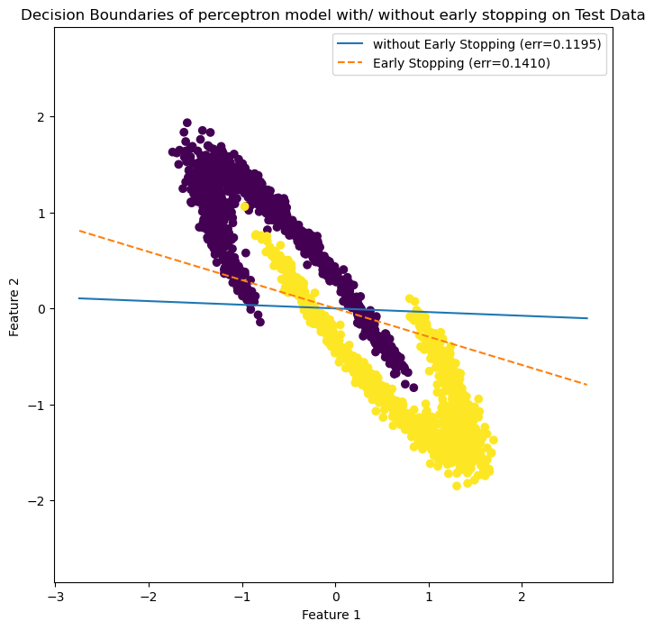

```python
# plot the decision boundary for the perceptron model with and without early stopping

print("best perceptron model with and without early stopping：")
test_error_es = zero_one_loss(label_test, best_model_early_stopping['model'].predict(X_test_scaled))
print(f"best perceptron model without early stopping: {best_model_no_stopping['params']}, Test Error: {best_model_no_stopping['error']:.4f}")
print(f"best perceptron model with early stopping: {best_model_early_stopping['params']}, Final Test Error: {test_error_es:.4f}")

# Plot the decision boundaries of the two best models on the same plot
plt.figure(figsize=(8, 8))

plt.scatter(x=X_test_scaled[:,0], y=X_test_scaled[:,1], c=label_test)
plt.title('Decision Boundaries of perceptron model with/ without early stopping on Test Data')

# Plot the decision boundary
def plot_perceptron_boundary(model, label, linestyle):
    w = model.coef_[0]
    b = model.intercept_[0]
    x_points = np.linspace(X_test_scaled[:, 0].min() - 1, X_test_scaled[:, 0].max() + 1, 10)
    # Decision boundary is a linear equation: w1*x1 + w2*x2 + b = 0  to  x2 = (-w1/w2)*x1 - b/w2
    y_points = -(w[0] / w[1]) * x_points - b / w[1]
    plt.plot(x_points, y_points, label=label, linestyle=linestyle)

# plot the decision boundary for best model without early stopping
plot_perceptron_boundary(best_model_no_stopping['model'], f"without Early Stopping (err={best_model_no_stopping['error']:.4f})", '-')

# plot the decision boundary for best model with early stopping
plot_perceptron_boundary(best_model_early_stopping['model'], f"Early Stopping (err={test_error_es:.4f})", '--')

plt.xlabel("Feature 1 ")
plt.ylabel("Feature 2 ")
plt.legend()
plt.ylim(X_test_scaled[:, 1].min() - 1, X_test_scaled[:, 1].max() + 1)
plt.show()
```

### Q2-III

### Train two 3-layer neural network models with different L2 regularisation strengths: one with λ = 0.001 and the other with λ = 1.0. For both models, evaluate combinations of hidden layer sizes K ∈ {5, 10, 15, ..., 40}, (i.e. from 5 to 40 with a step size of 5) and learning rates η ∈ {0.001, 0.01, 0.1}. Calculate and record testing error for each of them. Find the best combination of K and η for both models. Then, plot the decision boundaries of each model alongside the test data in two separate plots. Based on the test errors and the decision boundary plots, explain which model performs better

```python
# plot the decision boundary for neural network models
def plot_NNmodel_decision_boundary(pred_func):
    # Set min and max values and give it some padding
    x_min, x_max = X[:, 0].min() - .5, X[:, 0].max() + .5
    y_min, y_max = X[:, 1].min() - .5, X[:, 1].max() + .5
    h = 0.01
    # Generate a grid of points with distance h between them
    xx, yy = np.meshgrid(np.arange(x_min, x_max, h), np.arange(y_min, y_max, h))
    # Predict the function value for the whole gid
    # ravel: Flatten the array to a one-dimensional array    c_ :Combining arrays by column
    Z = pred_func(np.c_[xx.ravel(), yy.ravel()])
    Z = Z.reshape(xx.shape)
    # Plot the contour and training  data points
    plt.contourf(xx, yy, Z, cmap=plt.cm.Spectral)
    plt.scatter(X[:, 0], X[:, 1], c=y, cmap=plt.cm.Spectral)
```

```python
# calculate loss of the model
def calculate_loss(model, X_train, y_train):
    W1, b1, W2, b2 = model['W1'], model['b1'], model['W2'], model['b2']
    # Forward propagation to calculate our predictions
    z1 = X_train.dot(W1) + b1
    a1 = np.tanh(z1)
    z2 = a1.dot(W2) + b2

    # get the softmax probability
    exp_scores = np.exp(z2)
    probs = exp_scores / np.sum(exp_scores, axis=1, keepdims=True)
    # Calculating the loss
    corect_logprobs = -np.log(probs[range(len(X_train)), y_train])
    data_loss = np.sum(corect_logprobs)
    # Add regulatization term to loss
    data_loss += L2_lambda/2 * (np.sum(np.square(W1)) + np.sum(np.square(W2)))
    return 1./len(X_train) * data_loss
```

```python
# define the prediction functiion
def predict(model, x):
    W1, b1, W2, b2 = model['W1'], model['b1'], model['W2'], model['b2']
    # Forward propagation
    z1 = x.dot(W1) + b1
    a1 = np.tanh(z1)
    z2 = a1.dot(W2) + b2
    # Prevent out-of-range values
    z2_stable = z2 - np.max(z2, axis=1, keepdims=True)
    #  get the softmax probability
    exp_scores = np.exp(z2_stable)
    probs = exp_scores / np.sum(exp_scores, axis=1, keepdims=True)
    # Return the cluster with the highest probability
    return np.argmax(probs, axis=1)
```

```python
# define the Neural Network Model
def NeuralNetworkModel(nn_input_dim, nn_hdim, X_train, y_train, X_test, y_test, num_examples, eta, epoch_max=40000, print_loss=False):
    # init the parameters
    np.random.seed(0)
    W1 = np.random.randn(nn_input_dim, nn_hdim) / np.sqrt(nn_input_dim)
    b1 = np.zeros((1, nn_hdim))
    W2 = np.random.randn(nn_hdim, nn_output_dim) / np.sqrt(nn_hdim)
    b2 = np.zeros((1, nn_output_dim))

    model = {}
    test_error_list = []
    # running the epoch
    for i in np.arange(0, epoch_max):

        # Forward propagation
        z1 = X_train.dot(W1) + b1
        a1 = np.tanh(z1)
        z2 = a1.dot(W2) + b2
        # Subtract the maximum value from each row to ensure numerical stability
        z2_stable = z2 - np.max(z2, axis=1, keepdims=True)
        #  get the softmax probability
        exp_scores = np.exp(z2_stable)
        probs = exp_scores / np.sum(exp_scores, axis=1, keepdims=True)

        # Backpropagation and Calculate the gradient of each parameter
        L3 = probs
        # error of output
        L3[range(num_examples), y_train] -= 1

        dW2 = (a1.T).dot(L3)
        db2 = np.sum(L3, axis=0, keepdims=True)

        det2 = L3.dot(W2.T) * (1 - np.power(a1, 2))
        dW1 = np.dot(X_train.T, det2)
        db1 = np.sum(det2, axis=0)

        dW2 += L2_lambda * W2
        dW1 += L2_lambda * W1

        # Gradient descent parameter update
        W1 += -eta * dW1
        b1 += -eta * db1
        W2 += -eta * dW2
        b2 += -eta * db2

        model = { 'W1': W1, 'b1': b1, 'W2': W2, 'b2': b2}

        # return the test error
        if i == epoch_max - 1:
            final_test_error = zero_one_loss(predict(model, X_test).flatten(), y_test)

    return final_test_error, model
```

```python
# Define the dimensions of each layer
nn_input_dim = 2
nn_hdim = 3
nn_output_dim = 2

# init the lambda
L2_lambda = 0.0
```

```python
# Defining the parameter combination
neuron_count_list = np.arange(5, 41, 5)
learning_rate_list = [0.001, 0.01, 0.1]
lambda_values = [0.001, 1.0]
```

```python
# Store the optimal model information for the two lambda cases
best_nn_models = {}

# loop two lambda values
for lam in lambda_values:
    print(f"\n----- model with λ = {lam} and different k, η：-----")
    L2_lambda = lam  # set the lambda values

    best_error = 1.0
    best_params = {}
    results_list = []

    for K in neuron_count_list:
        for eta in learning_rate_list:
            # loop Different lamda and learning rate
            test_error, _ = NeuralNetworkModel(
                nn_input_dim, K, features_train, label_train, features_test, label_test,
                features_train.shape[0], eta, epoch_max=15000
            )

            print(f"  K={K}, η={eta}, Test Error={test_error:.4f}")
            results_list.append({'K': K, 'η': eta, 'Test Error': test_error})

            if test_error < best_error:
                best_error = test_error
                best_params = {'K': K, 'η': eta}

    print(f"\n----- model with λ = {lam} best result： -----")
    print(f"best parameter : {best_params}, the lowest error: {best_error:.4f}")
    # record the best model
    best_nn_models[lam] = {
        'params': best_params,
        'error': best_error,
        'results_df': pd.DataFrame(results_list)
    }
```

```
----- model with λ = 0.001 and different k, η：-----
  K=5, η=0.001, Test Error=0.0010
  K=5, η=0.01, Test Error=0.1330
  K=5, η=0.1, Test Error=0.5000
  K=10, η=0.001, Test Error=0.0010
  K=10, η=0.01, Test Error=0.0020
  K=10, η=0.1, Test Error=0.2325
  K=15, η=0.001, Test Error=0.0020
  K=15, η=0.01, Test Error=0.0020
  K=15, η=0.1, Test Error=0.1000
  K=20, η=0.001, Test Error=0.0020
  K=20, η=0.01, Test Error=0.0020
  K=20, η=0.1, Test Error=0.0020
  K=25, η=0.001, Test Error=0.0020
  K=25, η=0.01, Test Error=0.0070
  K=25, η=0.1, Test Error=0.0150
  K=30, η=0.001, Test Error=0.0015
  K=30, η=0.01, Test Error=0.0045
  K=30, η=0.1, Test Error=0.0960
  K=35, η=0.001, Test Error=0.0015
  K=35, η=0.01, Test Error=0.0050
  K=35, η=0.1, Test Error=0.1170
  K=40, η=0.001, Test Error=0.0015
  K=40, η=0.01, Test Error=0.0070
  K=40, η=0.1, Test Error=0.1335

----- model with λ = 0.001 best result： -----
best parameter : {'K': np.int64(5), 'η': 0.001}, the lowest error: 0.0010

----- model with λ = 1.0 and different k, η：-----
  K=5, η=0.001, Test Error=0.0055
  K=5, η=0.01, Test Error=0.0055
  K=5, η=0.1, Test Error=0.5000
  K=10, η=0.001, Test Error=0.0060
  K=10, η=0.01, Test Error=0.1545
  K=10, η=0.1, Test Error=0.5000
  K=15, η=0.001, Test Error=0.0055
  K=15, η=0.01, Test Error=0.0055
  K=15, η=0.1, Test Error=0.5000
  K=20, η=0.001, Test Error=0.0050
  K=20, η=0.01, Test Error=0.0800
  K=20, η=0.1, Test Error=0.5000
  K=25, η=0.001, Test Error=0.0060
  K=25, η=0.01, Test Error=0.0370
  K=25, η=0.1, Test Error=0.5000
  K=30, η=0.001, Test Error=0.0060
  K=30, η=0.01, Test Error=0.1340
  K=30, η=0.1, Test Error=0.5000
  K=35, η=0.001, Test Error=0.0080
  K=35, η=0.01, Test Error=0.1750
  K=35, η=0.1, Test Error=0.5000
  K=40, η=0.001, Test Error=0.0060
  K=40, η=0.01, Test Error=0.1070
  K=40, η=0.1, Test Error=0.5000

----- model with λ = 1.0 best result： -----
best parameter : {'K': np.int64(20), 'η': 0.001}, the lowest error: 0.0050
```

[output not shown]

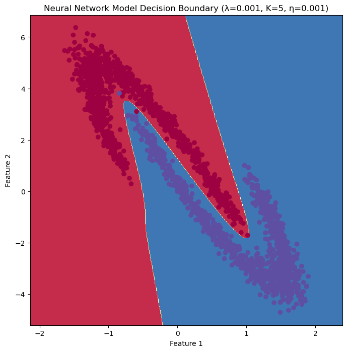

[output not shown]

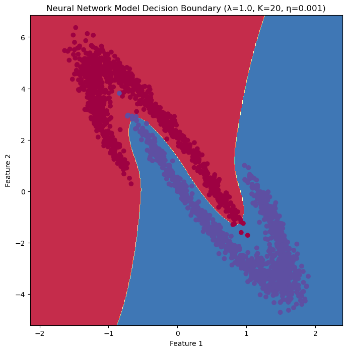

```
--- Comparison of Neural Network Model Performance ---
the best error of model with λ = 0.001 : 0.0010
the best error of model with λ = 1.0 : 0.0050
```

```python
# Plot the decision boundaries for the two optimal models.
for lam, details in best_nn_models.items():
    print(f" Plot the decision boundaries for optimal model with λ = {lam} ...")

    best_K = details['params']['K']
    best_eta = details['params']['η']

    # Retrain once using the best parameter combination to obtain the optimal model
    L2_lambda = lam
    _, best_model = NeuralNetworkModel(
        nn_input_dim, best_K, features_train, label_train, features_test, label_test,
        features_train.shape[0], best_eta, epoch_max=20000, print_loss=True
    )

    plt.figure(figsize=(8, 8))
    # Display the test data X, y data points in the plot
    X = features_test
    y = label_test
    plot_NNmodel_decision_boundary(lambda x: predict(best_model, x))
    plt.title(f'Neural Network Model Decision Boundary (λ={lam}, K={best_K}, η={best_eta})')
    plt.xlabel("Feature 1")
    plt.ylabel("Feature 2")
    plt.show()

# Comparing the performance of two models
error_lam_001 = best_nn_models[0.001]['error']
error_lam_1 = best_nn_models[1.0]['error']

print("\n--- Comparison of Neural Network Model Performance ---")
print(f"the best error of model with λ = 0.001 : {error_lam_001:.4f}")
print(f"the best error of model with λ = 1.0 : {error_lam_1:.4f}")
```

### Based on the test errors and the decision boundary plots, explain which model performs better

From the two plots of the decision boundary, we can see that the model with λ=0.001, K=5, η=0.001 performs better at the boundary than the model with λ=1.0, K=20, η=0.001. The actual test error also shows that the model with λ=0.001, K=5, η=0.001 has a lower test error. Therefore, the model with λ=0.001, K=5, η=0.001 is the better model.

### Q2-IV

### Explain the reason(s) responsible for such difference between Perceptron and a 3-layer NeuralNetwork by comparing the plots you generated in Steps II and III.

As shown in the figure above, the decision boundary of the perceptron model can only linearly separate the data, while the three-layer neural network can nonlinearly separate the different classes. This is because the perceptron model assumes that its training data is linearly separable, and its decision boundary is also linear.

However, real data is nonlinearly separable and requires nonlinear transformations for effective classification. Furthermore, three-layer neural networks can perform nonlinear transformations through nonlinear activation functions and hidden layers, enabling them to learn nonlinear data. This is why three-layer neural networks are better at classifying nonlinear data.